# Regression Model

Nick Orka

1/6/2020

## Executive Summary

This work for Motor Trend, a magazine about the automobile industry. Looking at a data set of a collection of cars, they are interested in exploring the relationship between a set of variables and miles per gallon (MPG) (outcome). They are particularly interested in the following two questions:

- “Is an automatic or manual transmission better for MPG”
- “Quantify the MPG difference between automatic and manual transmissions”

## Exploratory Analysis

```r
str(mtcars)
```

```
## 'data.frame':    32 obs. of  11 variables:
##  $ mpg : num  21 21 22.8 21.4 18.7 18.1 14.3 24.4 22.8 19.2 ...
##  $ cyl : num  6 6 4 6 8 6 8 4 4 6 ...
##  $ disp: num  160 160 108 258 360 ...
##  $ hp  : num  110 110 93 110 175 105 245 62 95 123 ...
##  $ drat: num  3.9 3.9 3.85 3.08 3.15 2.76 3.21 3.69 3.92 3.92 ...
##  $ wt  : num  2.62 2.88 2.32 3.21 3.44 ...
##  $ qsec: num  16.5 17 18.6 19.4 17 ...
##  $ vs  : num  0 0 1 1 0 1 0 1 1 1 ...
##  $ am  : num  1 1 1 0 0 0 0 0 0 0 ...
##  $ gear: num  4 4 4 3 3 3 3 4 4 4 ...
##  $ carb: num  4 4 1 1 2 1 4 2 2 4 ...
```

```r
df <- within(mtcars, {
   vs <- factor(vs, labels = c("V", "S"))
   am <- factor(am, labels = c("automatic", "manual"))
   cyl  <- factor(cyl)
   gear <- factor(gear)
   carb <- factor(carb)
})
summary(df)
```

```
##       mpg        cyl         disp             hp             drat
##  Min.   :10.40   4:11   Min.   : 71.1   Min.   : 52.0   Min.   :2.760
##  1st Qu.:15.43   6: 7   1st Qu.:120.8   1st Qu.: 96.5   1st Qu.:3.080
##  Median :19.20   8:14   Median :196.3   Median :123.0   Median :3.695
##  Mean   :20.09          Mean   :230.7   Mean   :146.7   Mean   :3.597
##  3rd Qu.:22.80          3rd Qu.:326.0   3rd Qu.:180.0   3rd Qu.:3.920
##  Max.   :33.90          Max.   :472.0   Max.   :335.0   Max.   :4.930
##        wt             qsec       vs             am     gear   carb
##  Min.   :1.513   Min.   :14.50   V:18   automatic:19   3:15   1: 7
##  1st Qu.:2.581   1st Qu.:16.89   S:14   manual   :13   4:12   2:10
##  Median :3.325   Median :17.71                         5: 5   3: 3
##  Mean   :3.217   Mean   :17.85                                4:10
##  3rd Qu.:3.610   3rd Qu.:18.90                                6: 1
##  Max.   :5.424   Max.   :22.90                                8: 1
```

## Regression Models

```r
ttest <- t.test(df[df$am == 'automatic', 'mpg'],df[df$am == 'manual', 'mpg'])
ttest
```

```
##
##  Welch Two Sample t-test
##
## data:  df[df$am == "automatic", "mpg"] and df[df$am == "manual", "mpg"]
## t = -3.7671, df = 18.332, p-value = 0.001374
## alternative hypothesis: true difference in means is not equal to 0
## 95 percent confidence interval:
##  -11.280194  -3.209684
## sample estimates:
## mean of x mean of y
##  17.14737  24.39231
```

Let’s check how mpg correlates with all other variables:

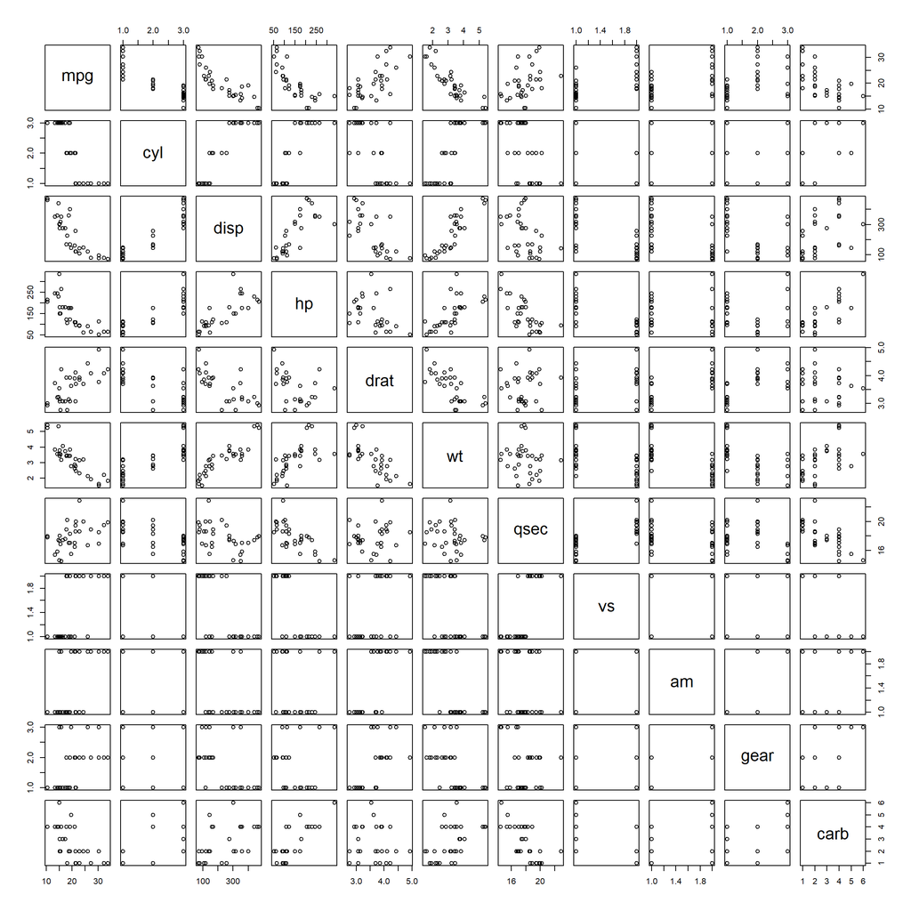

Let’s create direct model between MPG and AM variables.

```r
m1 <- lm(mpg ~ am, data = df)
summary(m1)
```

```
##
## Call:
## lm(formula = mpg ~ am, data = df)
##
## Residuals:
##     Min      1Q  Median      3Q     Max
## -9.3923 -3.0923 -0.2974  3.2439  9.5077
##
## Coefficients:
##             Estimate Std. Error t value Pr(>|t|)
## (Intercept)   17.147      1.125  15.247 1.13e-15 ***
## ammanual       7.245      1.764   4.106 0.000285 ***
## ---
## Signif. codes:  0 '***' 0.001 '**' 0.01 '*' 0.05 '.' 0.1 ' ' 1
##
## Residual standard error: 4.902 on 30 degrees of freedom
## Multiple R-squared:  0.3598, Adjusted R-squared:  0.3385
## F-statistic: 16.86 on 1 and 30 DF,  p-value: 0.000285
```

```r
m2 <- lm(mpg ~ am + disp, data = df)
m3 <- lm(mpg ~ am + disp + hp, data = df)
m4 <- lm(mpg ~ am + disp + hp + wt, data = df)
m5 <- lm(mpg ~ am + disp + hp + wt + qsec, data = df)
m <- c(am=m1$coef[2], disp=m2$coef[2], hp=m3$coef[2], wt=m4$coef[2], qsec=m5$coef[2])
m
```

```
##   am.ammanual disp.ammanual   hp.ammanual   wt.ammanual qsec.ammanual
##      7.244939      1.833458      3.796227      2.159271      3.470453
```

```r
summary(m)
```

```
##    Min. 1st Qu.  Median    Mean 3rd Qu.    Max.
##   1.833   2.159   3.470   3.701   3.796   7.245
```

It shows us that manual transmission coefficient allways positive, no matter what variable we do include in the models.

```r
anova(m1, m2, m3, m4, m5)
```

```
## Analysis of Variance Table
##
## Model 1: mpg ~ am
## Model 2: mpg ~ am + disp
## Model 3: mpg ~ am + disp + hp
## Model 4: mpg ~ am + disp + hp + wt
## Model 5: mpg ~ am + disp + hp + wt + qsec
##   Res.Df    RSS Df Sum of Sq       F    Pr(>F)
## 1     30 720.90
## 2     29 300.28  1    420.62 71.2732 6.354e-09 ***
## 3     28 226.10  1     74.18 12.5694  0.001511 **
## 4     27 179.91  1     46.20  7.8279  0.009558 **
## 5     26 153.44  1     26.47  4.4853  0.043908 *
## ---
## Signif. codes:  0 '***' 0.001 '**' 0.01 '*' 0.05 '.' 0.1 ' ' 1
```

In this comparison we can see that there are other variables that are statistically significant. Let’s take a look at the model with all of them:

```r
summary(m5)
```

```
##
## Call:
## lm(formula = mpg ~ am + disp + hp + wt + qsec, data = df)
##
## Residuals:
##     Min      1Q  Median      3Q     Max
## -3.5399 -1.7398 -0.3196  1.1676  4.5534
##
## Coefficients:
##             Estimate Std. Error t value Pr(>|t|)
## (Intercept) 14.36190    9.74079   1.474  0.15238
## ammanual     3.47045    1.48578   2.336  0.02749 *
## disp         0.01124    0.01060   1.060  0.29897
## hp          -0.02117    0.01450  -1.460  0.15639
## wt          -4.08433    1.19410  -3.420  0.00208 **
## qsec         1.00690    0.47543   2.118  0.04391 *
## ---
## Signif. codes:  0 '***' 0.001 '**' 0.01 '*' 0.05 '.' 0.1 ' ' 1
##
## Residual standard error: 2.429 on 26 degrees of freedom
## Multiple R-squared:  0.8637, Adjusted R-squared:  0.8375
## F-statistic: 32.96 on 5 and 26 DF,  p-value: 1.844e-10
```

Now the variance in MPG is exaplained better with the inclussion of other variables (R-squared=86%). The p-value also is less than 0.05. Finally, check for homoskedastic in the appendix and according to the behaviour of the residuals this assumption holds.

## Conclusion

Manual transmission inscreases MPG by means of 3.47, which is exact match for the median of different models.

## Appendix

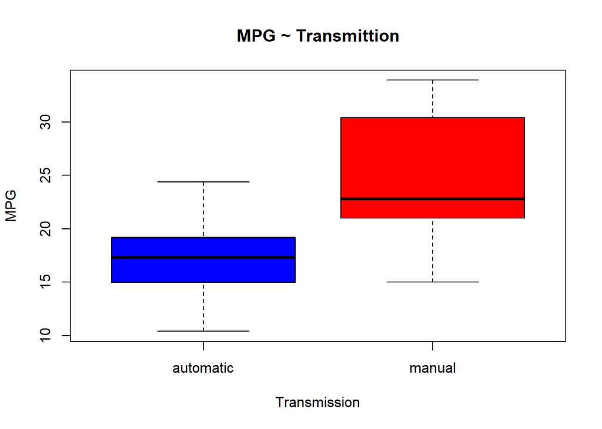

```r
boxplot(mpg~am,data = df,col=c('blue','red'),ylab='MPG',xlab='Transmission',main='MPG ~ Transmittion')
```

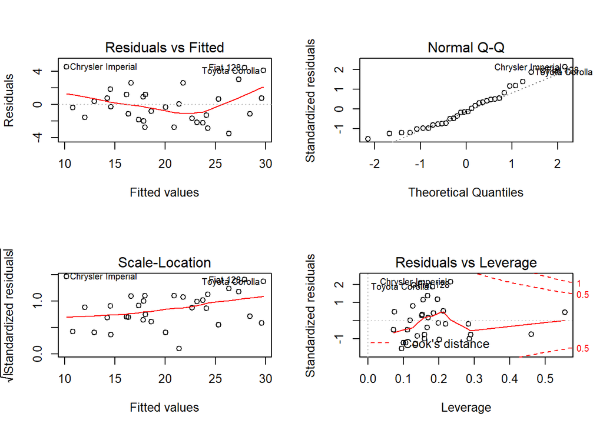

```r
par(mfrow = c(2,2))
plot(m5)
```